# Spatial risk modeling - HW

Yichao Jia

November 28, 2018

## **Data Wrangling**

Let’s start with the map after we join the assaults to fishnet. (code blocks are not shown because they are the same as HW instructions)

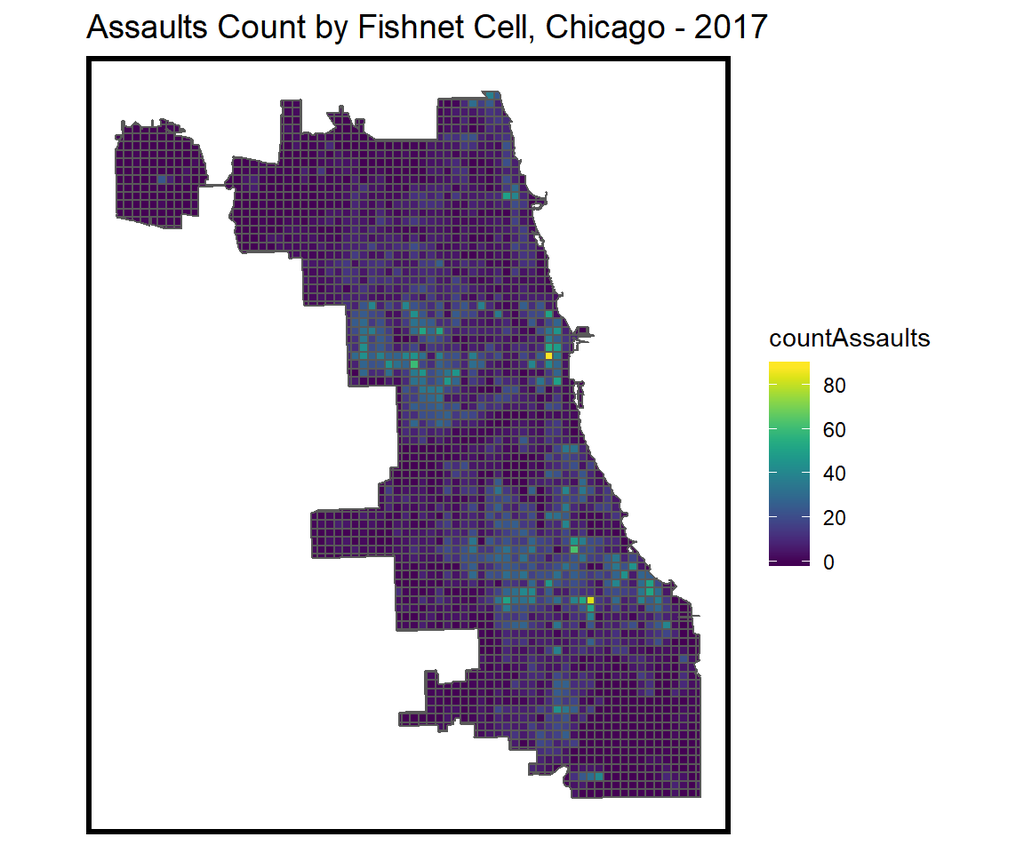

In order to build a better version of the given model, I downloaded other features from Chicago’s data portal that are possibly related to crime presence, including 311 reports of alley lights-out, sanitation complaints, grafitti removal requests, rodent baiting requests, park locations, and police station locations, etc.

In addition, several new features are added:

- the count of service requests complaining sanitation code violation
- the count of service requests of rodent baiting (indicative of the presence of rats)
- the distance to five nearest parks’ centroids
- the distance to the nearest police station
- the distance to five nearest parks’ centroid

Below is the code for collecting and wrangling these independent variables.  
First let’s get the count of lights-out incidents and their locations:

```r
streetLightsOut <-
  read.socrata("https://data.cityofchicago.org/Service-Requests/311-Service-Requests-Street-Lights-All-Out/zuxi-7xem") %>%
  mutate(year = substr(Creation.Date,1,4)) %>%
  filter(year == "2017") %>%
  dplyr::select(Latitude,Longitude, Y = Latitude, X = Longitude) %>%
  na.omit() %>%
  st_as_sf(coords = c("X", "Y"), crs = 4326, agr = "constant") %>%
  st_sf() %>%
  st_transform(st_crs(fishnet)) %>%
  mutate(Legend = "Lights_Out")


alleyLightsOut <-
  read.socrata("https://data.cityofchicago.org/Service-Requests/311-Service-Requests-Alley-Lights-Out-No-Duplicate/up7z-t43p") %>%
  mutate(year = substr(Creation.Date,1,4)) %>%
  filter(year == "2017") %>%
  dplyr::select(Latitude,Longitude, Y = Latitude, X = Longitude) %>%
  na.omit() %>%
  st_as_sf(coords = c("X", "Y"), crs = 4326, agr = "constant") %>%
  st_sf() %>%
  st_transform(st_crs(fishnet)) %>%
  mutate(Legend = "Lights_Out")

lightsOut <-
  rbind(streetLightsOut,alleyLightsOut)
```

Similarly, we can get the locations of schools, sanitation code violation, rodent baiting and graffiti removal requests:

```r
school <- read.csv("D:/18FALL/SPATIAL_ANALYTICS/11/CPS_School_Locations_SY1415.csv") %>%
  st_as_sf(coords = c("X", "Y"), crs = 4326, agr = "constant") %>%
  dplyr::select(geometry) %>%
  st_sf() %>%
  st_transform(st_crs(fishnet)) %>%
  mutate(Legend = "School")


sanitationComplaints <-
  read.socrata("https://data.cityofchicago.org/Service-Requests/311-Service-Requests-Sanitation-Code-Complaints/me59-5fac") %>%
  mutate(year = substr(Creation.Date,1,4)) %>%
  filter(year == "2017") %>%
  dplyr::select(Latitude,Longitude, Y = Latitude, X = Longitude) %>%
  na.omit() %>%
  st_as_sf(coords = c("X", "Y"), crs = 4326, agr = "constant") %>%
  st_sf() %>%
  st_transform(st_crs(fishnet)) %>%
  mutate(Legend = "Sanitation_complaints")


rodentBaiting <-
  read.socrata("https://data.cityofchicago.org/Service-Requests/311-Service-Requests-Rodent-Baiting-No-Duplicates/uqhs-j723") %>%
  mutate(year = substr(Creation.Date,1,4)) %>%
  filter(year == "2017") %>%
  dplyr::select(Latitude,Longitude, Y = Latitude, X = Longitude) %>%
  na.omit() %>%
  st_as_sf(coords = c("X", "Y"), crs = 4326, agr = "constant") %>%
  st_sf() %>%
  st_transform(st_crs(fishnet)) %>%
  mutate(Legend = "Rodent_complaints")


GraffitiRemoval <-
  read.socrata("https://data.cityofchicago.org/Service-Requests/311-Service-Requests-Graffiti-Removal-No-Duplicate/8tus-apua") %>%
  mutate(year = substr(Creation.Date,1,4)) %>%
  filter(year == "2017") %>%
  dplyr::select(Latitude,Longitude, Y = Latitude, X = Longitude) %>%
  na.omit() %>%
  st_as_sf(coords = c("X", "Y"), crs = 4326, agr = "constant") %>%
  st_sf() %>%
  st_transform(st_crs(fishnet)) %>%
  mutate(Legend = "Graffiti_removal")
```

Then join every set of event points to the fishnet.

```r
allVars.sf <-
  rbind(lightsOut,school,sanitationComplaints,
        rodentBaiting,GraffitiRemoval)

vars_net <-
  st_join(allVars.sf, fishnet, join=st_within) %>%
  as.data.frame() %>%
  group_by(uniqueID,Legend) %>%
  summarize(count = n()) %>%
  full_join(fishnet) %>%
  spread(Legend,count, fill=0) %>%
  st_sf() %>%
  na.omit()
```

Then we will move on to measure average nearest neighbor distance.  
First step is to create a function.

Now let’s calculate the average distance of each fishnet’s centroid to the nearest police station.

```r
nn_function <- function(measureFrom,measureTo,k) {

  nn <-
    get.knnx(measureTo, measureFrom, k)$nn.dist

  output <-
    as.data.frame(nn) %>%
    rownames_to_column(var = "thisPoint") %>%
    gather(points, point_distance, V1:ncol(.)) %>%
    arrange(as.numeric(thisPoint)) %>%
    group_by(thisPoint) %>%
    summarize(pointDistance = mean(point_distance)) %>%
    arrange(as.numeric(thisPoint)) %>%
    dplyr::select(-thisPoint)

  return(output)
}
```

```r
policeStation <-
  read.socrata("https://data.cityofchicago.org/Public-Safety/Police-Stations/z8bn-74gv") %>%
  dplyr::select(LATITUDE,LONGITUDE, Y = LATITUDE, X = LONGITUDE) %>%
  na.omit() %>%
  st_as_sf(coords = c("X", "Y"), crs = 4326, agr = "constant") %>%
  st_sf() %>%
  st_transform(st_crs(fishnet))

vars_net.xy <-
  st_centroid(vars_net) %>%
  cbind(.,st_coordinates(st_centroid(vars_net))) %>%
  st_set_geometry(NULL) %>%
  dplyr::select(X,Y) %>%
  as.matrix()

police.xy <-
  policeStation %>%
  cbind(.,st_coordinates(st_centroid(policeStation)))  %>%
  st_set_geometry(NULL) %>%
  dplyr::select(X,Y) %>%
  as.matrix()

distPolice <- as.data.frame(nn_function(vars_net.xy,police.xy,1))

vars_net <-
  cbind(as.data.frame(vars_net),distPolice) %>%
  st_sf() %>%
  rename(PoliceStadis=pointDistance)
```

As for parks, I tried k=2,3 and 5, and 5 turned out to be the best number for measuring near neighbor distance.

```r
parks <-
  st_read("D:/18FALL/SPATIAL_ANALYTICS/11/parks/park_centroid.shp") %>%
  st_transform(st_crs(fishnet))
parks.xy <-
  parks %>%
  cbind(.,st_coordinates(st_centroid(parks)))  %>%
  st_set_geometry(NULL) %>%
  dplyr::select(X,Y) %>%
  as.matrix()


distParks <- as.data.frame(nn_function(vars_net.xy,parks.xy,5))

vars_net <-
  cbind(as.data.frame(vars_net),distParks) %>%
  st_sf() %>%
  rename(Parkdistance=pointDistance)
```

As for abandoned buildings and liquor stores, I tested both count and distance methods in the regression model, and it turned out that the distance one yielded better results. Therefore, here we are going to calculate the distance to 5 nearest abandoned buildings and 5 nearest liquor stores.

```r
abandonBuildings <-
  read.socrata("https://data.cityofchicago.org/Service-Requests/311-Service-Requests-Vacant-and-Abandoned-Building/7nii-7srd") %>%
  mutate(year = substr(DATE.SERVICE.REQUEST.WAS.RECEIVED,1,4)) %>%
  filter(year == "2017") %>%
  dplyr::select(LATITUDE,LONGITUDE, Y = LATITUDE, X = LONGITUDE) %>%
  na.omit() %>%
  st_as_sf(coords = c("X", "Y"), crs = 4326, agr = "constant") %>%
  st_sf() %>%
  st_transform(st_crs(fishnet))

abandonBuildings.xy <-
  abandonBuildings %>%
  cbind(.,st_coordinates(st_centroid(abandonBuildings)))  %>%
  st_set_geometry(NULL) %>%
  dplyr::select(X,Y) %>%
  as.matrix()

distabandon <- as.data.frame(nn_function(vars_net.xy,abandonBuildings.xy,5))

vars_net <-
  cbind(as.data.frame(vars_net),distabandon) %>%
  st_sf() %>%
  rename(AbandonBuildingdis=pointDistance)
```

```r
liquorRetail <-
  read.socrata("https://data.cityofchicago.org/Community-Economic-Development/Business-Licenses-Current-Liquor-and-Public-Places/nrmj-3kcf") %>%
  filter(BUSINESS.ACTIVITY == "Retail Sales of Packaged Liquor") %>%
  dplyr::select(LATITUDE,LONGITUDE, Y = LATITUDE, X = LONGITUDE) %>%
  na.omit() %>%
  st_as_sf(coords = c("X", "Y"), crs = 4326, agr = "constant") %>%
  st_sf() %>%
  st_transform(st_crs(fishnet))

liquor.xy <-
  liquorRetail %>%
  cbind(.,st_coordinates(st_centroid(liquorRetail)))  %>%
  st_set_geometry(NULL) %>%
  dplyr::select(X,Y) %>%
  as.matrix()

distLiquor <- as.data.frame(nn_function(vars_net.xy,liquor.xy,5))

vars_net <-
  cbind(as.data.frame(vars_net),distLiquor) %>%
  st_sf() %>%
  rename(Liquordistance=pointDistance)
```

From the same dataset for liquor stores I also extract data for another type of business which opens during late hours, hoping that would be statistically associated with our safety issue. Then let’s measure the distance of each cell centroid to the nearest late-hour business.

```r
lateHour <-
  read.socrata("https://data.cityofchicago.org/Community-Economic-Development/Business-Licenses-Current-Liquor-and-Public-Places/nrmj-3kcf") %>%
  filter(LICENSE.DESCRIPTION == "Late Hour") %>%
  dplyr::select(LATITUDE,LONGITUDE, Y = LATITUDE, X = LONGITUDE) %>%
  na.omit() %>%
  st_as_sf(coords = c("X", "Y"), crs = 4326, agr = "constant") %>%
  st_sf() %>%
  st_transform(st_crs(fishnet))

lateHour.xy <-
  lateHour %>%
  cbind(.,st_coordinates(st_centroid(lateHour)))  %>%
  st_set_geometry(NULL) %>%
  dplyr::select(X,Y) %>%
  as.matrix()

distlateHour <- as.data.frame(nn_function(vars_net.xy,lateHour.xy,1))

vars_net <-
  cbind(as.data.frame(vars_net),distlateHour) %>%
  st_sf() %>%
  rename(lateHourdis=pointDistance)
```

The feature “distance to loop” in the original model is kept in this model as a feature to indicate the proximaty to commercial center.

```r
neighborhoods <-
  st_read("https://raw.githubusercontent.com/blackmad/neighborhoods/master/chicago.geojson") %>%
  st_transform(st_crs(fishnet))
loopPoint <-
  neighborhoods %>%
  filter(name == "Loop") %>%
  st_centroid()

vars_net$loopDistance =
  st_distance(st_centroid(vars_net),loopPoint) %>%
  as.numeric()
```

Finally we connect all the predictors to our dependent variable. And below you can find the head of all the independent variables that are used in the model later.

```r
final_net <-
  left_join(crime_net,data.frame(vars_net), by="uniqueID") %>%
  dplyr::select(-geometry,-geometry.y)

head(final_net)
```

```
## Simple feature collection with 6 features and 14 fields
## geometry type:  POLYGON
## dimension:      XY
## bbox:           xmin: 359653.4 ymin: 552875.4 xmax: 362577.3 ymax: 553375.4
## epsg (SRID):    102271
## proj4string:    +proj=tmerc +lat_0=36.66666666666666 +lon_0=-88.33333333333333 +k=0.9999749999999999 +x_0=300000 +y_0=0 +ellps=GRS80 +towgs84=0,0,0,0,0,0,0 +units=m +no_defs
##   countAssaults uniqueID Graffiti_removal Lights_Out Rodent_complaints
## 1             5        1                0         15                 1
## 2             0        2                0          0                 0
## 3             0        3                0          0                 0
## 4             0        4                0          0                 0
## 5             0        5                0          0                 0
## 6             0        6                0          0                 0
##   Sanitation_complaints School X.NA. PoliceStadis Parkdistance
## 1                     3      0     0     5166.713     2689.696
```

[output cut: 19 more lines]

## **Exploratory anlaysis**

To start I am going to do some exploratory mapping of independent variables.

The plot of nearest neighbor distance to schools showed in class displayed very small variation across the city. So I think that maybe, compared to each cell’s general distance to nearby schools, the presence and the exact number of schools in the cell is more related to the assualts happened in that area. The count of schools by fishnet unit is presented below. In this way the variation is much easier to be observed.

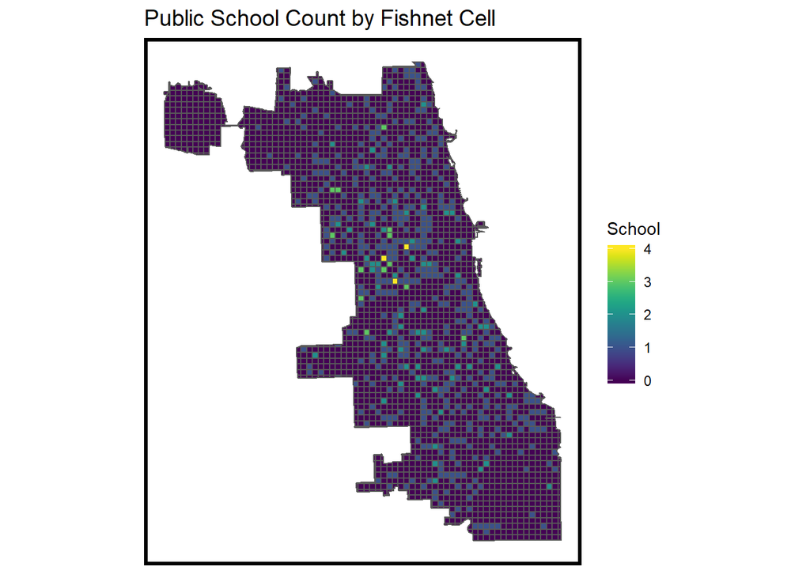

And here are the mapping of the average nearest neighbor distance of police station and late hour business.

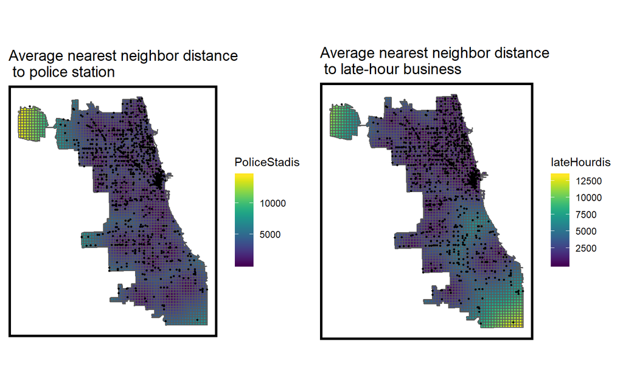

Also, let’s take a look at the relationship between these predictors and dependent variables.

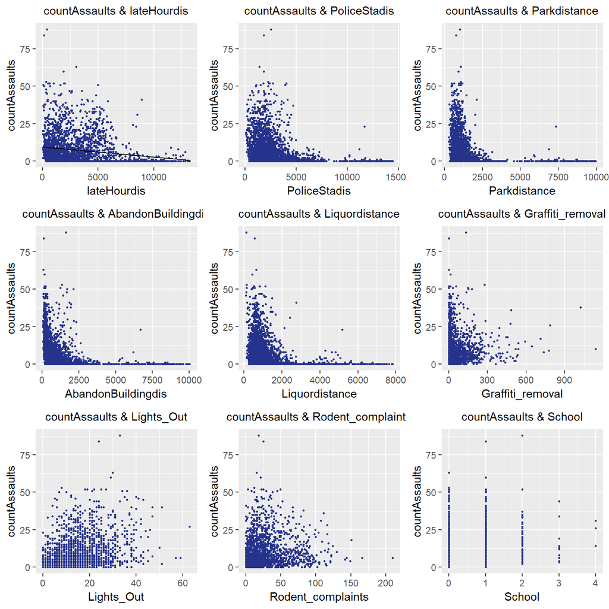

## **Estimate models**

Now we move on to the regression model. The code block below builds our regression model and returns the result summary.

```r
reg <- glm(countAssaults ~ ., family = "poisson",
           data= final_net %>%
             as.data.frame %>%
             dplyr::select(countAssaults,
                           AbandonBuildingdis,
                           Graffiti_removal,
                           School,
                           Lights_Out,
                           Rodent_complaints,
                           Sanitation_complaints,
                           PoliceStadis,
                           Liquordistance,
                           Parkdistance,
                           lateHourdis,
                           loopDistance
             ))
summary(reg)
```

```
##
## Call:
## glm(formula = countAssaults ~ ., family = "poisson", data = final_net %>%
##     as.data.frame %>% dplyr::select(countAssaults, AbandonBuildingdis,
##     Graffiti_removal, School, Lights_Out, Rodent_complaints,
##     Sanitation_complaints, PoliceStadis, Liquordistance, Parkdistance,
##     lateHourdis, loopDistance))
##
## Deviance Residuals:
##     Min       1Q   Median       3Q      Max
## -9.4254  -1.8146  -0.7831   0.5116  20.0692
##
## Coefficients:
##                           Estimate   Std. Error z value
## (Intercept)            3.041268269  0.036331865  83.708
## AbandonBuildingdis    -0.000628418  0.000019356 -32.467
## Graffiti_removal      -0.000908929  0.000086086 -10.558
## School                 0.219690743  0.010580389  20.764
## Lights_Out             0.025335961  0.000769595  32.921
## Rodent_complaints     -0.001956449  0.000336304  -5.818
## Sanitation_complaints  0.011566354  0.000494757  23.378
## PoliceStadis          -0.000110951  0.000007902 -14.042
## Liquordistance        -0.000464346  0.000024098 -19.269
## Parkdistance          -0.000203365  0.000026907  -7.558
## lateHourdis            0.000028920  0.000005104   5.666
## loopDistance          -0.000020164  0.000001969 -10.238
##                                   Pr(>|z|)
## (Intercept)           < 0.0000000000000002 ***
## AbandonBuildingdis    < 0.0000000000000002 ***
## Graffiti_removal      < 0.0000000000000002 ***
## School                < 0.0000000000000002 ***
## Lights_Out            < 0.0000000000000002 ***
## Rodent_complaints       0.0000000059732036 ***
## Sanitation_complaints < 0.0000000000000002 ***
## PoliceStadis          < 0.0000000000000002 ***
## Liquordistance        < 0.0000000000000002 ***
## Parkdistance            0.0000000000000409 ***
## lateHourdis             0.0000000146091421 ***
## loopDistance          < 0.0000000000000002 ***
## ---
## Signif. codes:  0 '***' 0.001 '**' 0.01 '*' 0.05 '.' 0.1 ' ' 1
##
## (Dispersion parameter for poisson family taken to be 1)
##
##     Null deviance: 28873  on 2659  degrees of freedom
## Residual deviance: 13915  on 2648  degrees of freedom
## AIC: 21052
##
## Number of Fisher Scoring iterations: 6
```

As shown in the results, all the variable coefficients are statistically significant. We then standardize the coefficients to put them on the same scale. As can be seen from the bar chart below, the nearest neighbor distance to abandoned buildings and liquor stores have the largest effects on assaults presence.

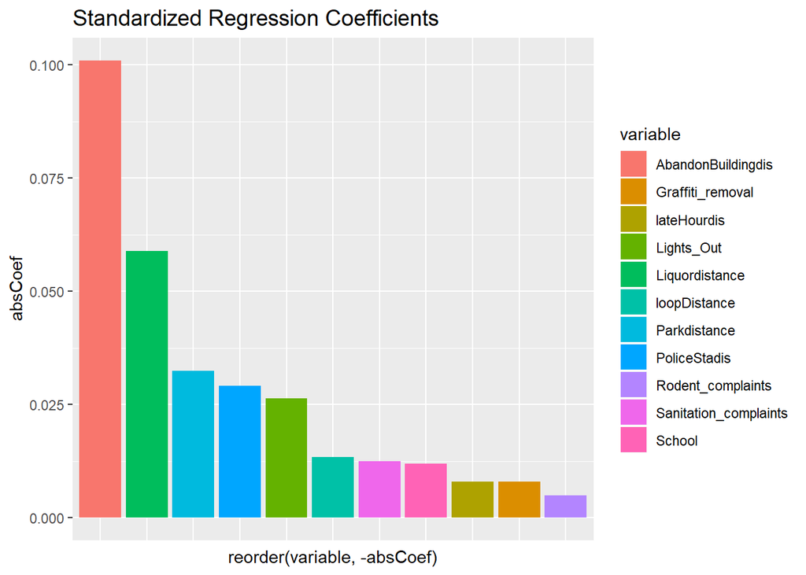

```r
standardized <- as.data.frame(lm.beta(reg))
standardized$variable <- row.names(standardized)
colnames(standardized)[1] <- "std_coefficient"

standardized$absCoef <- abs(standardized$std_coefficient)

ggplot(standardized, aes(x=reorder(variable,-absCoef), y=absCoef, fill=variable)) +
  geom_bar(stat="identity") +
  labs(title="Standardized Regression Coefficients") +
  theme(plot.title = element_text(size = 14,colour = "black"),
        axis.text.x=element_blank(),
        axis.ticks.x=element_blank()
        )
```

```r
range(reg$fitted.values)
```

```
## [1]  0.00003098604 62.00821603131
```

Then let’s generate a map of predicted assault counts. We can see that this map is pretty consistent with the map we have in the beginning, the one showing the distribution of the observed assualts by fishnet units.

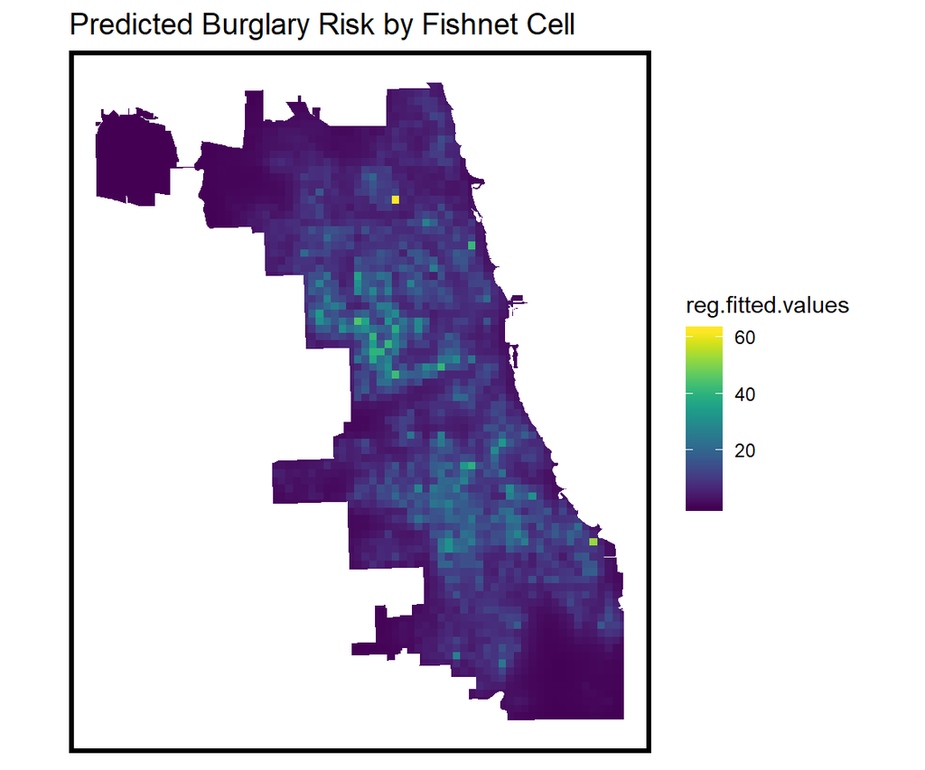

```r
ggplot() +
  geom_sf(data=cbind(fishnet,reg$fitted.values), aes(fill=reg.fitted.values), colour=NA) +
  labs(title= "Predicted Burglary Risk by Fishnet Cell") +
  scale_fill_viridis() +
  mapTheme()
```

Then we generate another map showing the average predicted risk by police beat.

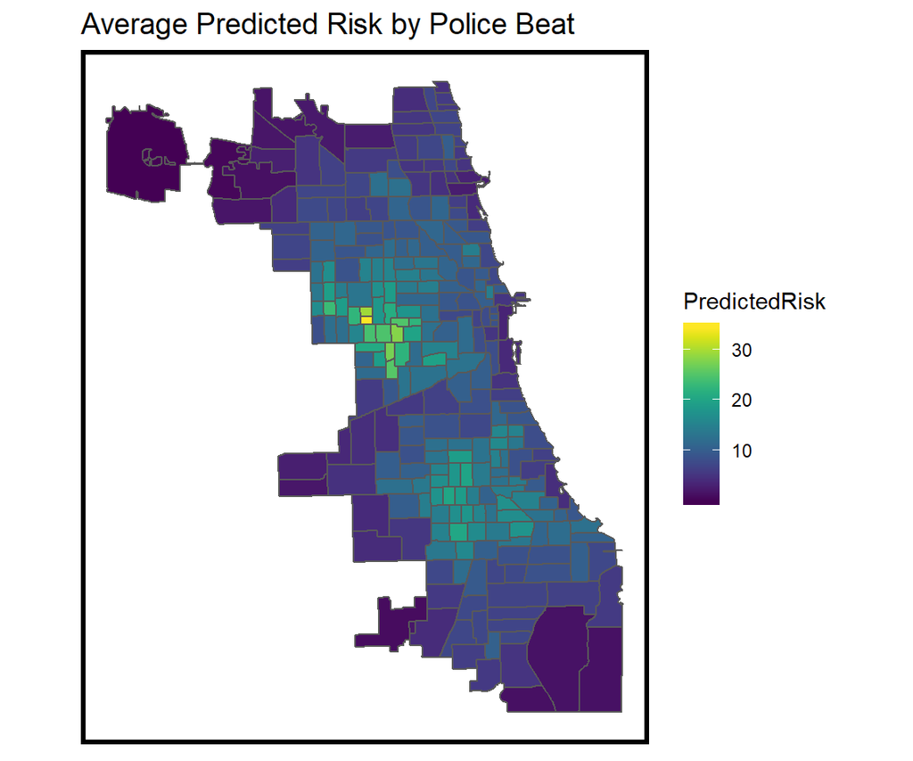

```r
crime_beat <-
  cbind(fishnet,reg$fitted.values) %>%
  rename(PredictedRisk=reg.fitted.values) %>%
  st_transform(st_crs(policeBeats)) %>%
  aggregate(., policeBeats, mean) %>%
  dplyr::select(-uniqueID)


ggplot() +
  geom_sf(data=crime_beat, aes(fill=PredictedRisk)) +
  scale_fill_viridis() +
  labs(title= "Average Predicted Risk by Police Beat") +
  mapTheme()
```

## **Goodness of fit**

Based on the model prediction results we can calculate the MAE(Mean Absolute Error) and MAPE(Mean Absolute Percentage Error). Because there are many 0 value in assualt count it is a little wierd to compute MAPE, as I remove many infinite values from the dataset.  
For this model the MAE is 4.412, which is slightly better than the original model, and MAPE is 1.003.

```r
final_net <-
  cbind(final_net,reg$fitted.values) %>%
  rename(predictedValue = reg.fitted.values) %>%
  mutate(absError = abs(countAssaults - predictedValue)) %>%
  mutate(pctabsError = abs(countAssaults - predictedValue)/countAssaults)

is.na(final_net$pctabsError) <- sapply(final_net$pctabsError, is.infinite)

MAE <-  mean(final_net$absError)
MAPE <-  mean(na.omit(final_net$pctabsError))
```

Then let’s see how the absolute error distributes across the city based on the unit of fishnet cell.

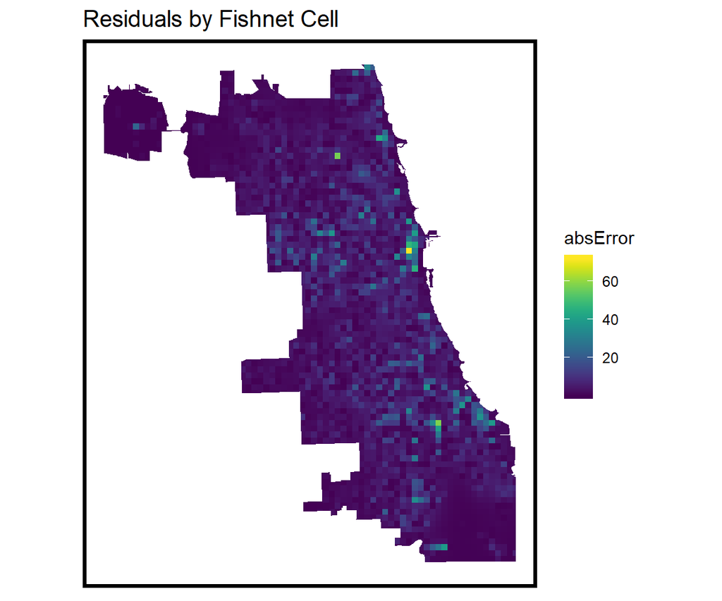

We will also plot a map showing the mean absolute error by neighborhood. As can be observed from below, the general goodness of fit is not too bad, and the absolute error goes higher in areas adjacent to Chicago’s Central Business District. That probably makes sense as the crime pattern becomes more unpredictable due to high density of population and activities.

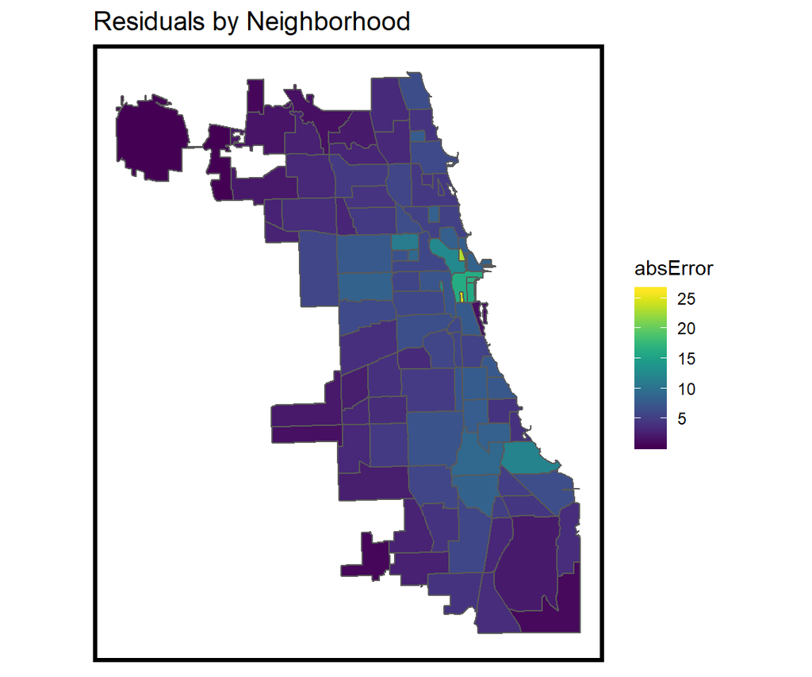

```r
neighborhood_error <-
  final_net %>%
  st_transform(st_crs(neighborhoods)) %>%
  aggregate(., neighborhoods, mean) %>%
  dplyr::select(predictedValue,absError,pctabsError )


ggplot() +
  geom_sf(data=neighborhood_error, aes(fill=absError)) +
  scale_fill_viridis() +
  labs(title= "Residuals by Neighborhood") +
  mapTheme()
```

Then we move on to create the kernel density vs. risk prediction plot. According to the plot, the areas that our model predict as high risk (70%~100%) hold larger percentage of observed assualts than the high risk area predicted by kernel density. Also, in the areas that are predicted as low risk (1%~49%) by our model, there are smaller percentage of actual assualts that fall inside compared to the ones predicted by kernel density. This indicates that our model is doing a better job than kernel density.

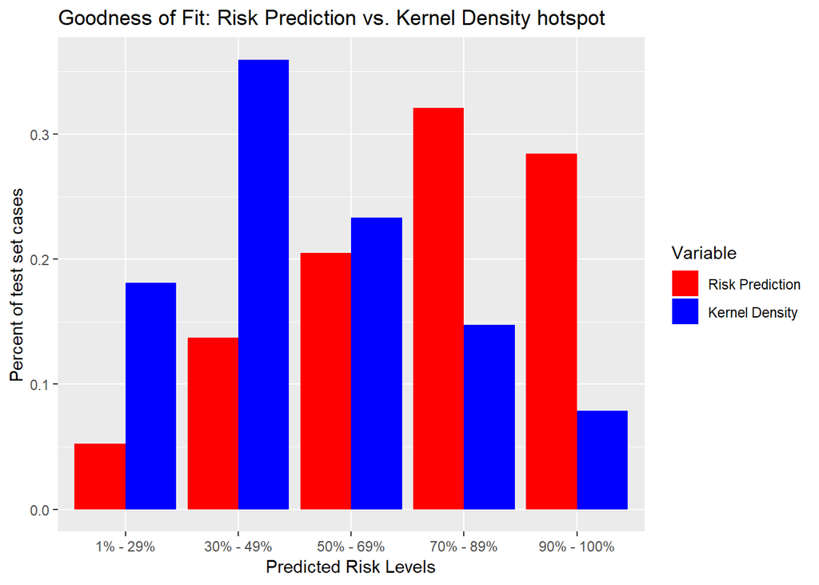

## **Interpretation**

Given the use case, the model is comparatively successful. According to the maps, the high risk areas this model predicts are almost the same as the areas with high density of assualt presence in reality. Based on its prediction, the cops may assign more resources to the high-risk areas to prevent some potential assualts from happening.